# DSCI 100 - Introduction to Data Science

## Lecture 6 - Classification using K-Nearest Neighbours

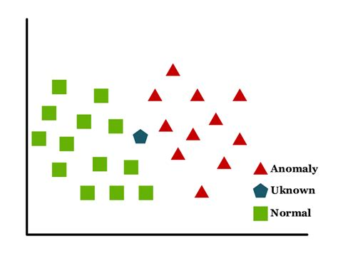

# Outline for today

- Few admin notes (Housekeeping)
- Brief recap of last class (on Whiteboard)
- Overview of content for today (Classification using K-Nearest Neighbours)
- Brief demo

### Housekeeping

**Midterm**

- Your midterm is the week after Reading Week (Week 7 Tutorial, Thursday 26th Feb)
- Midterm will cover topics from weeks 1-6
- Closed-book Canvas quiz (multiple choice, short answer, and fill-in-the-blank questions)
- Requires Lock Down Browser (LDB)
- Instructions posted on Canvas; practice quiz to be posted soon

### Reminder

Where are we? Where are we going?

[figure not shown]

*source: [R for Data Science](https://r4ds.had.co.nz/) by Grolemund & Wickham*

## Classification

Suppose we have past data of cancer tumour cell diagnosis labelled "benign" and "malignant".

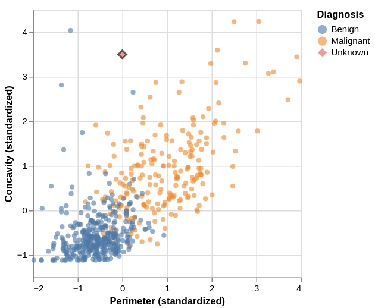

## What kind of data analysis question is this?

- descriptive
- exploratory
- predictive
- inferential
- causal
- mechanistic

## K-nearest neighbours classification

*Predict the label / class for a new observation using the K closest points from our dataset.*

1. Compute the distance between the new observation and each observation in our *training set*

$\text{Distance} = \sqrt{(a_{\text{x}} - b_{\text{x}})^2 + (a_{\text{y}} - b_{\text{y}})^2}$

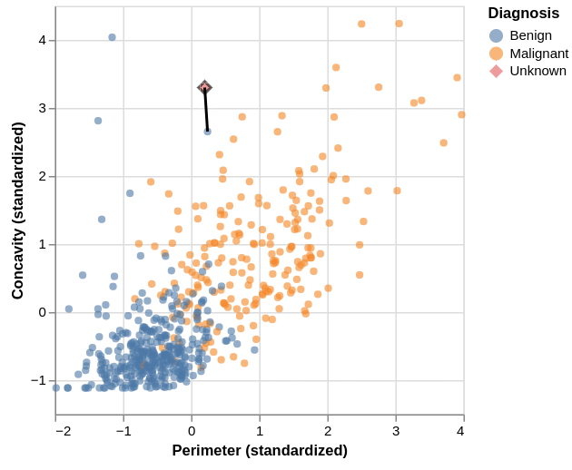

## K-nearest neighbours classification

*Predict the label / class for a new observation using the K closest points from our dataset.*

2. Choose the top K rows with the shortest distances as the "neighbours" (here, K=3)

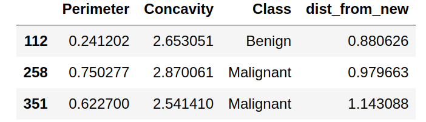

## K-nearest neighbours classification

*Predict the label / class for a new observation using the K closest points from our dataset.*

3. Classify the new observation based on majority vote.

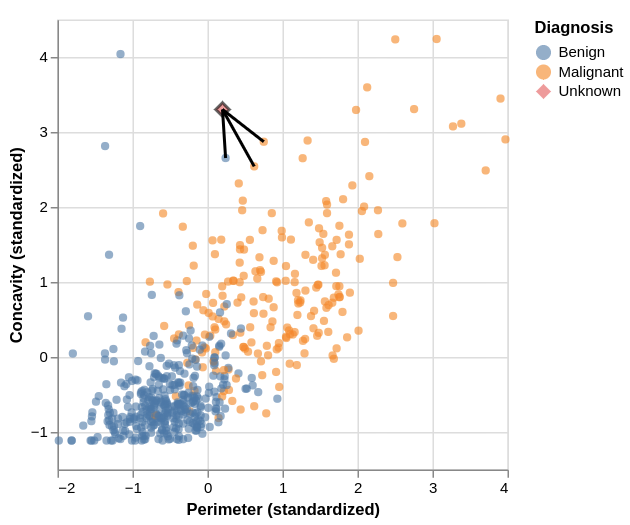

### What would the predicted class be?

## We can go beyond 2 predictors

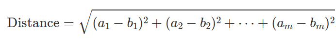

Aside from that, it's the same algorithm!

## Standardizing Data

[figure not shown]

## Nonstandardized Data

What if one variable is much larger than the other?

[figure not shown]

## Nonstandardized Data vs Standardized Data

What if one variable is much larger than the other?

*Standardize:* shift and scale so that the average is 0 and the standard deviation is 1.

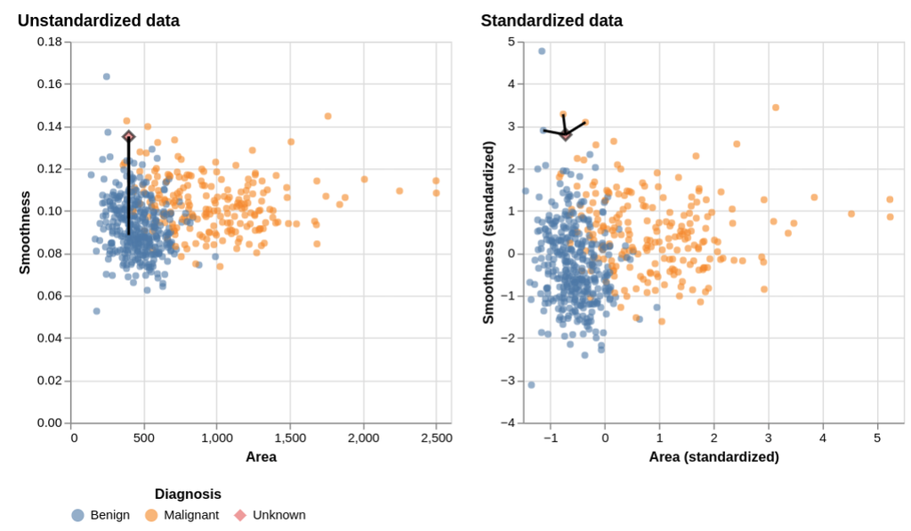

## Introduction to the `scikit-learn` library in Python

scikit-learn is a machine learning library in Python. It can handle things like computing distances, standardization, balancing, and prediction for us!

0. Load the libraries and data we need

```python
import pandas as pd


cancer = pd.read_csv("data/clean-wdbc.data.csv")
```

## Introduction to the `scikit-learn` library in Python

0b. Inspect the data

```python
cancer
```

## Introduction to the `scikit-learn` library in Python

### 1. Preprocess the data with `sklearn.compose` and `sklearn.preprocessing`.

```python
from sklearn.compose import make_column_transformer
from sklearn.preprocessing import StandardScaler
from sklearn import set_config

# Output dataframes instead of arrays
set_config(transform_output="pandas")
```

```python
# setting what kind of transformation we are doing (standard scaling)
# picking the columns on whcih the transformation is to be perfromed
preprocessor = make_column_transformer(
    (StandardScaler(), ["Area", "Smoothness"]),
)
```

```python
# perfroming the transformation (fit & transform function) and saving the output
preprocessor.fit(cancer)
scaled_cancer = preprocessor.transform(cancer)
```

```python
scaled_cancer
```

## Introduction to the `scikit-learn` library in Python

### 2. Build a K-nearest Neighbors model with `sklearn.neighbors`

```python
from sklearn.neighbors import KNeighborsClassifier
```

```python
# use K=3 (default is 5)
knn = KNeighborsClassifier(n_neighbors=3)
```

```python
# perform the fit on the following data (setting the training data):
knn.fit(X=cancer[["Area", "Smoothness"]], y=cancer["Class"])
```

## Introduction to the `scikit-learn` library in Python

### 3. Put everything together in a `pipeline`

```python
from sklearn.pipeline import make_pipeline

preprocessor = make_column_transformer(
    (StandardScaler(), ["Area", "Smoothness"]),
)
knn = KNeighborsClassifier(n_neighbors=3)

pipe = make_pipeline(preprocessor, knn)

pipe.fit(X=cancer[["Area", "Smoothness"]], y=cancer["Class"])
```

## Introduction to the `scikit-learn` library in Python

### 4. Predict a new class label using `predict`

```python
# input the new data point and predict the class (B or M)
new_observation = pd.DataFrame({"Area": [400], "Smoothness": [0.136]})
pipe.predict(new_observation)
```

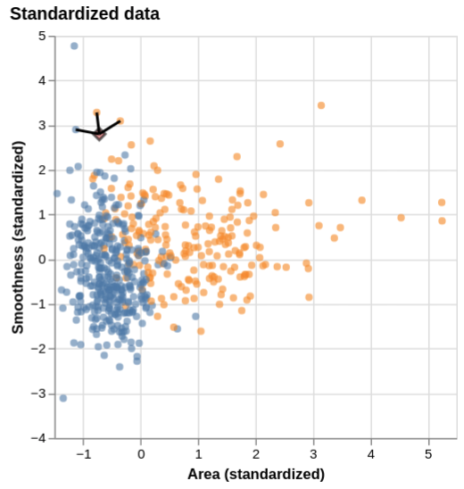

## Go forth and ... model?

[figure not shown]